# Correlation between EGFR status and primary location of lung cancer in nonsmokers

## 1. Introduction

EGFR mutation is significantly associated with adenocarcinoma(ADC). EGFR overexpression leads to loss of cell cycle control which can cause ADC. According to our resource paper ‘Proteogenomics of Non-smoking Lung Cancer in East Asia Delineates Molecular Signatures of Pathogenesis and Progression’, EGFR mutation is a main characteristic of lung adenocarcinoma(LUAD) in East Asia. This paper gives a data about early stage lung cancer patients in Taiwan(TW) such as age, gender, histology type, EGFR status, and primary tumor location.

## 2. Data visualizing

```r
library(dplyr)
library(tidyverse)
library(readxl)
library(ggplot2)
dataS1A = read_excel("mmc1.xlsx", sheet = 2)
```

Let’s find the correlation between primary tumor location and EGFR status by point plots.

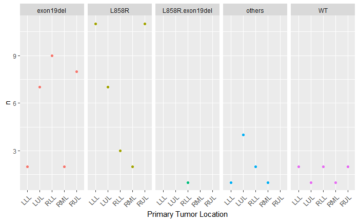

[figure not shown]

```r
dataS1A %>%
  filter(`Histology Type` == "ADC" & `Smoking Status` == "Nonsmoke") %>%
  group_by(`Primary Tumor Location`, EGFR_Status) %>%
  count() %>%
  ggplot(aes(`Primary Tumor Location`, n)) +
  geom_point(aes(col = EGFR_Status), show.legend = FALSE) +
  theme(axis.text.x = element_text(angle = 45, hjust = 1, size = 10)) +
  facet_grid(.~EGFR_Status)
```

## 4. Reference

Yi-Ju Chen, Theodoros I. Roumeliotis, Ya-Hsuan Chang, Ching-Tai Chen, Chia-Li Han, Miao-Hsia Lin, Huei-Wen Chen, Gee-Chen Chang, Yih-Leong Chang, Chen-Tu Wu, Mong-Wei Lin, Min-Shu Hsieh, Yu-Tai Wang, Yet-Ran Chen, Inge Jonassen, Fatemeh Zamanzad Ghavidel, Ze-Shiang Lin, Kuen-Tyng Lin, Ching-Wen Chen, Pei-Yuan Sheu, Chen-Ting Hung, Ke-Chieh Huang, Hao-Chin Yang, Pei-Yi Lin, Ta-Chi Yen, Yi-Wei Lin, Jen-Hung Wang, Lovely Raghav, Chien-Yu Lin, Yan-Si Chen, Pei-Shan Wu, Chi-Ting Lai, Shao-Hsing Weng, Kang-Yi Su, Wei-Hung Chang, Pang-Yan Tsai, Ana I. Robles, Henry Rodriguez, Yi-Jing Hsiao, Wen-Hsin Chang, Ting-Yi Sung, Jin-Shing Chen, Sung-Liang Yu, Jyoti S. Choudhary, Hsuan-Yu Chen, Pan-Chyr Yang, Yu-Ju Chen, Proteogenomics of Non-smoking Lung Cancer in East Asia Delineates Molecular Signatures of Pathogenesis and Progression, Cell, Volume 182, Issue 1, 2020, Pages 226-244.e17

Wikipedia, Epidermal growth factor receptor ( https://en.wikipedia.org/wiki/Epidermal_growth_factor_receptor#Cancer )